# CENT: Bioinformatics Research Scientist

Take-home Assignment

Natalia Silva Morosini

April 09, 2026

**This document performs Part 1 - Part 5 of the take-home assignment.**

# 1 **PART 1 - Data Exploration and Quality Control**

## 1.1 Setup

```r
library(tidyverse)
library(readr)
library(data.table)
```

```r
library(dplyr)
library(ggplot2)
library(tidyr)
library(naniar)
library(UpSetR)
library(ggfortify)
library(edgeR)
library(limma)
library(ComplexHeatmap)
library(circlize)
```

## 1.2 Load Data

I began this analysis by loading the five available datasets (clinical, metabolomics, radiomics, RNA-seq counts, and RNA-seq metadata) and inspecting basic dimensions, column names, and identifiers. At this stage, my goal was simply to understand what constitutes a ‘sample’ in each modality.

```r
clinical   <- read.csv("data/clinical.csv")
radiomics  <- read.csv("data/radiomics.csv")
metabol    <- read.csv("data/metabolomics.csv")
rnameta    <- read_delim("data/rnaseq_metadata.tsv", delim = ",")
rnacounts_raw <- fread("data/rnaseq_counts.tsv", data.table = FALSE)

# Create directory "part1"
if (!dir.exists("part1"))
  dir.create("part1")
```

## 1.3 RNAseq Preprocessing

My first attempt to load the count matrix with gene identifiers as row names failed due to duplicated row names.

```r
colnames(rnacounts_raw)[1] <- "genes"

rnacounts_raw <- rnacounts_raw %>%
  filter(!is.na(genes), genes != "")

rnacounts_raw$genes <- make.unique(rnacounts_raw$genes)

rownames(rnacounts_raw) <- rnacounts_raw$genes
rnacounts <- rnacounts_raw[, -1, drop = FALSE]
rnacounts[] <- lapply(rnacounts, as.numeric)
rnacounts <- as.matrix(rnacounts)
mode(rnacounts) <- "numeric"

rm(rnacounts_raw)
```

## 1.4 Clinical Overview

I next focused on describing the cohort using the clinical dataset, since it defines patient-level structure. I computed the number of unique patients and visits and produced a bar plot of the number of visits per patient. I initially assumed visit completeness would be roughly uniform, but the plot revealed substantial imbalance.

### 1.4.1 Number of Visits per Patient

```r
clinical %>%
  summarise(
    n_patients = n_distinct(patient_id),
    n_samples  = n_distinct(sample_id),
    max_visits = max(visit)
  )
```

```
##   n_patients n_samples max_visits
## 1         60       248          5
```

```r
clinical %>%
  count(patient_id, name = "num_patients") %>%
  count(num_patients, name = "num_visits")
```

```
##   num_patients num_visits
## 1            1          2
## 2            2          6
## 3            3         10
## 4            4          6
## 5            5         36
```

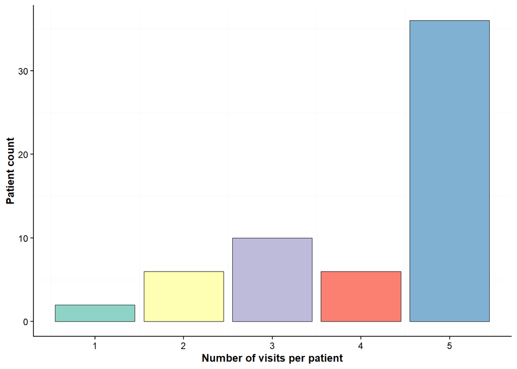

```r
p <-clinical %>%
  count(patient_id, name = "num_patients") %>%
  count(num_patients,name = "num_visits") %>%
  ggplot(aes(x = num_patients, y = num_visits, fill = factor(num_patients))) +
  geom_bar(position="stack",
           stat="identity",
           colour = "black",
           linewidth = 0.05) +
  xlab("Number of visits per patient") +
  ylab("Patient count") +
  guides(fill = "none") +
  scale_fill_brewer(palette = "Set3") +
  theme_classic() +
  theme(
    panel.grid.minor = element_line(color = "gray97"),
    axis.title.y = element_text(size = 10, color = "black", face = "bold"),
    axis.title.x = element_text(size = 10, color = "black", face = "bold"),
    axis.text.y = element_text(size = 9, color = "black"),
    axis.text.x = element_text(size = 9, color = "black"),
    legend.position = "none"  )

p
```

```r
ggsave("part1/clinical_patients_visit.png", p, height=2.8, width=4, dpi=300)
```

### 1.4.2 Block 1: Clinical Severity Markers

I also examined age, gender, subtype, and severity distributions, stratifying age by subtype and severity.

#### 1.4.2.1 Age Distributions by Subtype, Severity, and Gender

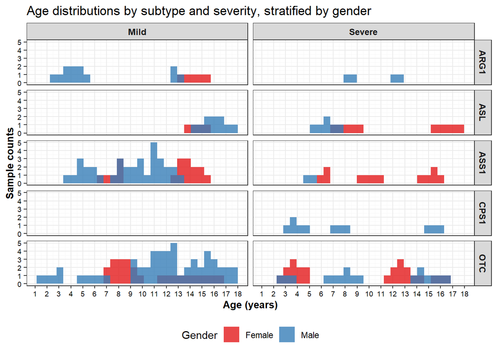

```r
clinical$sex <- factor(clinical$sex, levels = c("F", "M"))

p <-ggplot(clinical, aes(x = age, fill = sex)) +
  geom_histogram(
    bins = 30,
    alpha = 0.8,
    position = "identity"
  ) +
  facet_grid(subtype ~ severity,
             labeller = labeller(
             severity = c(mild = "Mild", severe = "Severe"))) +
  scale_fill_manual(
    values = c(F = "#E41A1C", M = "#377EB8"),
    labels = c(F = "Female", M = "Male")
  ) +
  scale_x_continuous(breaks = seq(1, 18, by = 1)) +
  labs(
    title = "Age distributions by subtype and severity, stratified by gender",
    x = "Age (years)",
    y = "Sample counts",
    fill = "Gender"
  ) +
  theme_bw() +
  theme(
      panel.grid.minor = element_line(color = "gray97"),
      axis.title.y = element_text(size = 10, color = "black", face = "bold"),
      axis.title.x = element_text(size = 10, color = "black", face = "bold"),
      axis.text.y = element_text(size = 7, color = "black"),
      axis.text.x = element_text(size = 7, color = "black"),
      strip.text = element_text(size = 9, face = "bold"),
      legend.position = "bottom")

p
```

```r
ggsave("part1/severity_vs.gender_age.png", p, height=5.4, width=6.8, dpi=300)
```

#### 1.4.2.2 Ammonia vs. age

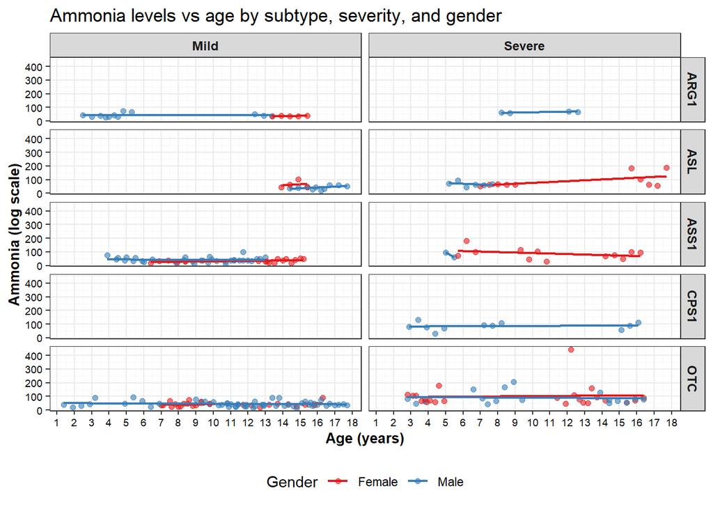

```r
p <- ggplot(clinical, aes(x = age, y = ammonia, color = sex)) +
  geom_point(alpha = 0.6, size = 1.6) +
  geom_smooth(
    method = "lm",
    se = FALSE,
    linewidth = 0.8
  ) +
  facet_grid(
    subtype ~ severity,
    labeller = labeller(severity = c(mild = "Mild", severe = "Severe"))
  ) +
  scale_color_manual(
    values = c(F = "#E41A1C", M = "#377EB8"),
    labels = c(F = "Female", M = "Male")
  ) +
  scale_y_log10(labels = scales::comma) +
  scale_y_continuous(breaks = seq(0, 400, by = 100)) +
  scale_x_continuous(breaks = seq(1, 18, by = 1)) +
  labs(
    title = "Ammonia levels vs age by subtype, severity, and gender",
    x = "Age (years)",
    y = "Ammonia (log scale)",
    color = "Gender"
  ) +
  theme_bw() +
  theme(
    panel.grid.minor = element_line(color = "gray97"),
    axis.title.y = element_text(size = 10, color = "black", face = "bold"),
    axis.title.x = element_text(size = 10, color = "black", face = "bold"),
    axis.text.y = element_text(size = 7, color = "black"),
    axis.text.x = element_text(size = 7, color = "black"),
    strip.text = element_text(size = 9, face = "bold"),
    legend.position = "bottom")
p
```

```r
ggsave("part1/ammonia_severity_vs.gender_age.png", p, height=5.4, width=7.2, dpi=300)
```

#### 1.4.2.3 NCS vs. age

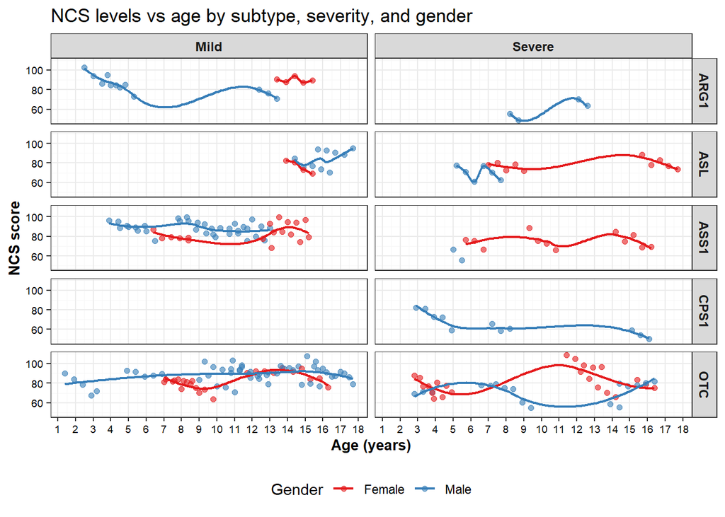

```r
p <- ggplot(clinical, aes(x = age, y = ncs, color = sex)) +
  geom_point(alpha = 0.6, size = 1.6) +
  geom_smooth(
    method = "loess",
    se = FALSE,
    linewidth = 0.8
  ) +
  facet_grid(
    subtype ~ severity,
    labeller = labeller(severity = c(mild = "Mild", severe = "Severe"))
  ) +
  scale_color_manual(
    values = c(F = "#E41A1C", M = "#377EB8"),
    labels = c(F = "Female", M = "Male")
  ) +  scale_x_continuous(breaks = seq(1, 18, by = 1)) +
  labs(
    title = "NCS levels vs age by subtype, severity, and gender",
    x = "Age (years)",
    y = "NCS score",
    color = "Gender"
  ) +
  theme_bw() +
  theme(
    panel.grid.minor = element_line(color = "gray97"),
    axis.title.y = element_text(size = 10, color = "black", face = "bold"),
    axis.title.x = element_text(size = 10, color = "black", face = "bold"),
    axis.text.y = element_text(size = 7, color = "black"),
    axis.text.x = element_text(size = 7, color = "black"),
    strip.text = element_text(size = 9, face = "bold"),
    legend.position = "bottom")

p
```

```r
ggsave("part1/ncs_severity_vs.gender_age.png", p, height=5.4, width=7.2, dpi=300)
```

**Interpretation:** NCS scores generally range between 60 and 100, with most values clustering at the higher end. Trend lines indicate that NCS tends to remain stable or increase slightly with age in mild cases, whereas severe cases show more variable and sometimes declining trajectories. Gender-specific differences are apparent in certain subtypes such as OTC, where male and female trend lines diverge. The narrow range of NCS in mild cases contrasts with the wider dispersion in severe cases, consistent with greater clinical heterogeneity in the severe group.

### 1.4.3 Block 2: Event Burden and Interventions

#### 1.4.3.1 Hyperammonemic Events (HAE)

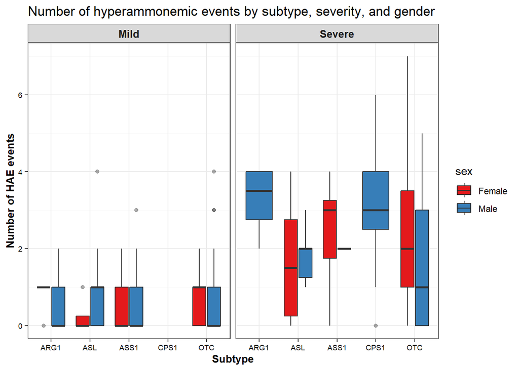

```r
p <-ggplot(clinical, aes(subtype, n_hae, fill = sex)) +
  geom_boxplot(outlier.alpha = 0.4) +
  facet_wrap(
    ~ severity,
    labeller = labeller(severity = c(mild = "Mild", severe = "Severe"))
  ) +
  scale_fill_manual(
    values = c(F = "#E41A1C", M = "#377EB8"),
    labels = c(F = "Female", M = "Male")
  ) +
  theme_bw() +
  labs(
    title = "Number of hyperammonemic events by subtype, severity, and gender",
    x = "Subtype",
    y = "Number of HAE events"
  ) +
  theme(
    panel.grid.minor = element_line(color = "gray97"),
    axis.title.y = element_text(size = 10, color = "black", face = "bold"),
    axis.title.x = element_text(size = 10, color = "black", face = "bold"),
    axis.text.y = element_text(size = 7, color = "black"),
    axis.text.x = element_text(size = 7, color = "black"),
    strip.text = element_text(size = 10, face = "bold"),
    legend.position = "right")

p
```

```r
ggsave("part1/hae_severity_vs.gender.png", p, height=4, width=6.8, dpi=300)
```

#### 1.4.3.2 Transplant Events

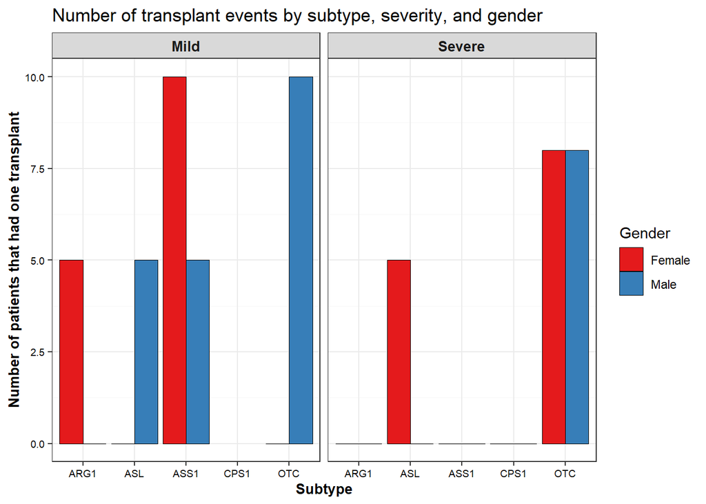

```r
p <- ggplot(clinical, aes(subtype, fill = sex, weight = transplant)) +
  geom_bar(position = "dodge",
           colour = "black",
           linewidth = 0.05) +
  facet_wrap(
    ~ severity,
    labeller = labeller(severity = c(mild = "Mild", severe = "Severe"))
  ) +
  scale_fill_manual(
    values = c(F = "#E41A1C", M = "#377EB8"),
    labels = c(F = "Female", M = "Male")
  ) +
  theme_bw() +
  labs(
    title = "Number of transplant events by subtype, severity, and gender",
    x = "Subtype",
    y = "Number of patients that had one transplant",
    fill = "Gender"
  ) +
  theme(
    panel.grid.minor = element_line(color = "gray97"),
    axis.title.y = element_text(size = 10, color = "black", face = "bold"),
    axis.title.x = element_text(size = 10, color = "black", face = "bold"),
    axis.text.y = element_text(size = 7, color = "black"),
    axis.text.x = element_text(size = 7, color = "black"),
    strip.text = element_text(size = 10, face = "bold"),
    legend.position = "right")

p
```

```r
ggsave("part1/transplant_severity_vs.gender.png", p, height=4, width=6.8, dpi=300)
```

**Interpretation:** Transplant events are concentrated in specific subtype-severity-gender combinations. In mild cases, ASS1 and OTC have the highest transplant counts with evident sex-based differences (more females in ASS1 mild, more males in OTC mild). In severe cases, OTC dominates transplant events with roughly equal representation between genders. ARG1 and CPS1 have minimal or no transplant events. This pattern suggests that transplant decisions are highly subtype-dependent and may also reflect severity-specific clinical trajectories and referral practices.

### 1.4.4 Block 3: Integrated Clinical Burden

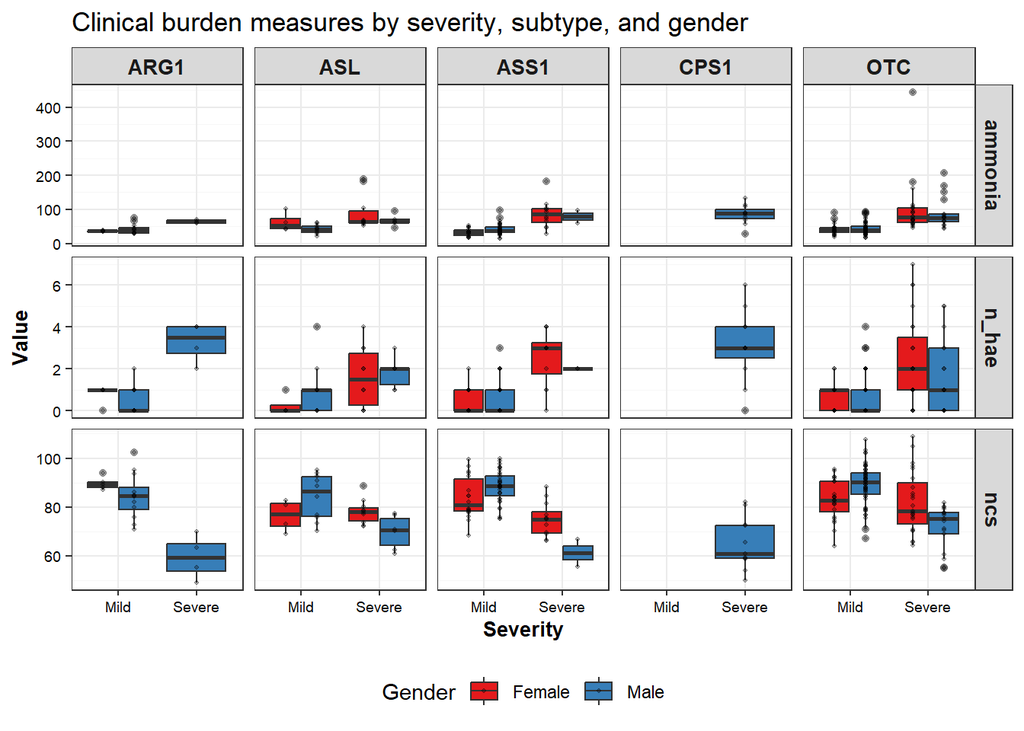

```r
clinical_long <- clinical %>%
  select(severity, subtype, sex, ammonia, ncs, n_hae) %>%
  pivot_longer(cols = c(ammonia, ncs, n_hae), names_to="measure", values_to="value")

p <- ggplot(clinical_long,
       aes(x = severity, y = value, fill = sex)) +
  geom_boxplot(
    position = position_dodge(width = 0.8),
    outlier.alpha = 0.4
  ) +
  geom_jitter(
    position = position_dodge(width = 0.8),
    alpha = 0.3,
    size = 0.8
  ) +
  facet_grid(
    measure ~ subtype,
    scales = "free_y"
  ) +
  scale_fill_manual(
    values = c(F = "#E41A1C", M = "#377EB8"),
    labels = c(F = "Female", M = "Male")
  ) +
  scale_x_discrete(labels = c(mild = "Mild", severe = "Severe")) +
  labs(
    title = "Clinical burden measures by severity, subtype, and gender",
    x = "Severity",
    y = "Value",
    fill = "Gender"
  ) +
  theme_bw() +
  theme(
    panel.grid.minor = element_line(color = "gray97"),
    axis.title.y = element_text(size = 10, color = "black", face = "bold"),
    axis.title.x = element_text(size = 10, color = "black", face = "bold"),
    axis.text.y = element_text(size = 7, color = "black"),
    axis.text.x = element_text(size = 7, color = "black"),
    strip.text = element_text(size = 10, face = "bold"),
    legend.position = "bottom")

p
```

```r
ggsave("part1/clinical_integrated.png", p, height=4, width=6.8, dpi=300)
```

**Interpretation:** The boxplots of ammonia, number of HAE events (n_hae), and NCS stratified by severity, subtype, and gender confirm that severe cases consistently have higher ammonia levels and more HAE events across most subtypes, while NCS values tend to be lower. Gender-based differences are visible but variable: some subtype panels show near-parity between males and females, while others exhibit clear separation. Individual data points reveal notable outliers, particularly in ammonia and HAE counts for severe patients, underscoring the skewed distribution of clinical burden.

### 1.4.5 Block 4: Multimodal QC Heatmap Interpretation

```r
dat <- clinical %>%
  dplyr::select(patient_id, visit, age, sex, subtype, severity) %>%
  left_join(radiomics,  by = c("patient_id", "visit")) %>%
  left_join(metabol,   by = c("patient_id", "visit"))

dat$sample_id.y <- NULL
colnames(dat)[7] <- "sample_id"

dat <- dat %>%
  mutate(age_bin = cut(age, breaks = c(0,5,10,15,20), include.lowest = TRUE))

num_cols <- dat %>%
  dplyr::select(-patient_id, -sample_id, -visit, -subtype, -severity, -sex, -age, -age_bin, -batch) %>%
  dplyr::select(where(is.numeric)) %>%
  colnames()

metabolomics_vars_raw <- colnames(metabol)[!(colnames(metabol) %in% c("patient_id","visit","batch"))]
radiomics_vars_raw <- colnames(radiomics)[!(colnames(radiomics) %in% c("patient_id","visit"))]

metabolomics_z <- paste0("z_", metabolomics_vars_raw)
radiomics_z <- paste0("z_", radiomics_vars_raw)

dat_z <- dat %>%
  group_by(subtype, severity, age_bin) %>%
  mutate(across(all_of(num_cols), ~ scale(.)[,1], .names = "z_{col}"))

dat_z <- dat_z %>%
  mutate(
    sex = recode(sex,
                 "F" = "Female",
                 "M" = "Male"),
    severity = recode(severity,
                      "mild" = "Mild",
                      "severe" = "Severe"),
    sex = factor(sex, levels = c("Female", "Male")),
    severity = factor(severity, levels = c("Mild", "Severe")),
    subtype = factor(subtype, levels = c("ARG1", "ASL", "ASS1", "CPS1", "OTC"))
  )

dat_z <- dat_z[order(dat_z$sex, dat_z$severity),]

z_cols <- grep("^z_", colnames(dat_z), value = TRUE)

top_deviation <- dat_z %>%
  rowwise() %>%
  mutate(
    # store the vector of z-scores as a list
    z_vals = list(c_across(all_of(z_cols))),

    # compute max deviation safely
    max_dev = if (all(is.na(z_vals[[1]]))) NA_real_
    else max(abs(z_vals[[1]]), na.rm = TRUE),

    # compute feature name safely
    max_feature = if (all(is.na(z_vals[[1]]))) NA_character_
    else z_cols[which.max(abs(z_vals[[1]]))]
  ) %>%
  ungroup() %>%
  dplyr::select(-z_vals)

top_deviation %>%
  group_by(patient_id, max_feature) %>%
  summarize(n = n(), mean_dev = mean(max_dev)) %>%
  arrange(desc(mean_dev))
```

```
## # A tibble: 67 × 4
## # Groups:   patient_id [60]
##    patient_id max_feature              n mean_dev
##    <chr>      <chr>                <int>    <dbl>
##  1 P034       z_total_brain_volume     5     1.35
##  2 P060       z_total_brain_volume     1     1.16
##  3 P018       z_total_brain_volume     5     1.15
##  4 P039       z_total_brain_volume     4     1.11
##  5 P040       z_total_brain_volume     3     1.10
##  6 P016       z_total_brain_volume     5     1.09
##  7 P010       z_total_brain_volume     5     1.08
##  8 P053       z_total_brain_volume     5     1.03
##  9 P012       z_total_brain_volume     5     1.01
## 10 P037       z_total_brain_volume     5     1.00
## # ℹ 57 more rows
```

```r
mat <- top_deviation %>%
  dplyr::select(sample_id, all_of(z_cols)) %>%
  column_to_rownames("sample_id") %>%
  as.matrix()

mat <- mat[rowSums(!is.na(mat)) > 0, ]

rownames(dat_z) <- dat_z$sample_id

row_annot_df <- data.frame(
  Gender = dat_z$sex,
  Severity = dat_z$severity,
  Subtype = dat_z$subtype,
  row.names = dat_z$sample_id
)

row_annot_df <- row_annot_df[rownames(mat), ]

row_annot <- HeatmapAnnotation(
  df = row_annot_df,
  col = list(
    Gender = c(Female = "#E41A1C", Male = "#377EB8"),
    Severity = c(Mild = "lightblue", Severe = "lightpink"),
    Subtype = c(
      ARG1 = "#A6CEE3", ASL = "#1F78B4", ASS1 = "#B2DF8A",
      CPS1 = "#33A02C", OTC = "#FB9A99"
    )
  ),
  which = "row"
)

modality_vec <- ifelse(colnames(mat) %in% metabolomics_z,
                       "Metabolomics", "Radiomics")

modality_vec <- factor(modality_vec,
                       levels = c("Metabolomics", "Radiomics"))

levels(modality_vec)
```

```
## [1] "Metabolomics" "Radiomics"
```

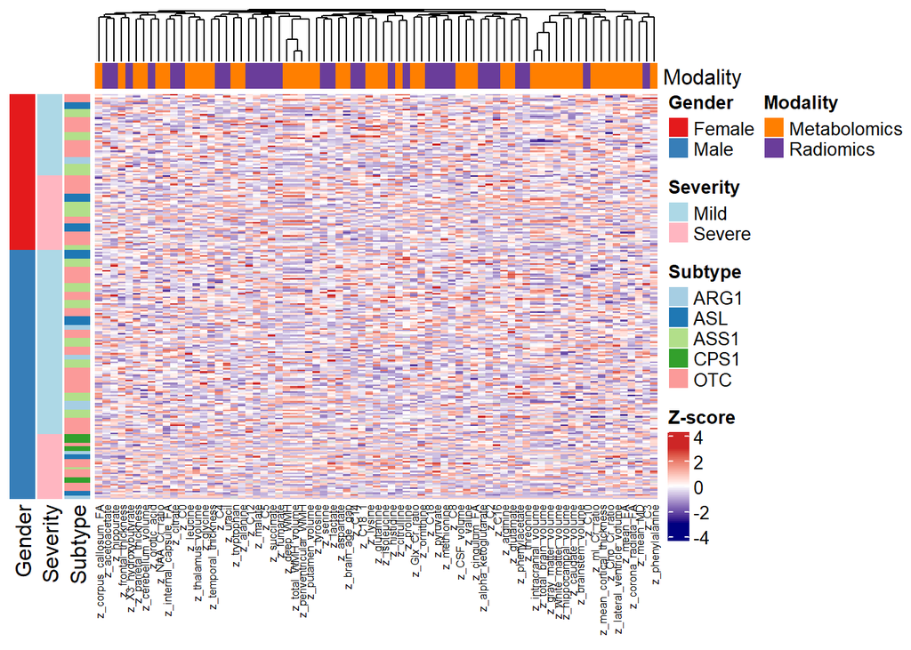

```r
modality_vec <- modality_vec[order(modality_vec)]

mat <- mat[, order(modality_vec)]

col_annot <- HeatmapAnnotation(
  Modality = modality_vec,
  col = list(
    Modality = c(
      Metabolomics = "#FF7F00",
      Radiomics = "#6A3D9A"
    )
  ),
  which = "column"
)

na_color <- "grey85"

p <- Heatmap(
  mat,
  name = "Z-score",
  col = colorRamp2(c(-3, 0, 3), c("navy", "white", "firebrick3")),
  top_annotation = col_annot,
  left_annotation = row_annot,
  cluster_rows = FALSE,
  cluster_columns = TRUE,
  show_row_names = FALSE,
  show_column_names = TRUE,
  column_names_gp = gpar(fontsize = 6),
  na_col = na_color
)

draw(p)
```

```r
png("part1/metabol_radio_integrated.png",
    width = 10, height = 6, units = "in", res = 300)
draw(p)
dev.off()
```

**Interpretation:** To evaluate cross‑modal consistency and assess data quality, a Z‑scored multimodal heatmap integrating radiomics and metabolomics features was generated. Columns are annotated by data modality, and rows are annotated by gender, disease severity, and genetic subtype. Radiomics and metabolomics features exhibit partial modality‑driven structure following hierarchical clustering, indicating comparable variance properties across modalities after Z‑scaling. At the sample level, patterns related to disease severity are subtle and do not dominate the unsupervised clustering, suggesting that severity‑associated signals are likely distributed across a subset of features rather than representing a primary axis of variation. Subtype‑associated patterns are also modest, consistent with biological and clinical heterogeneity within each subtype. Importantly, no samples display pronounced, multimodal deviations that would suggest technical artifacts, batch effects, or data integration failures.

## 1.5 Missingness Overview

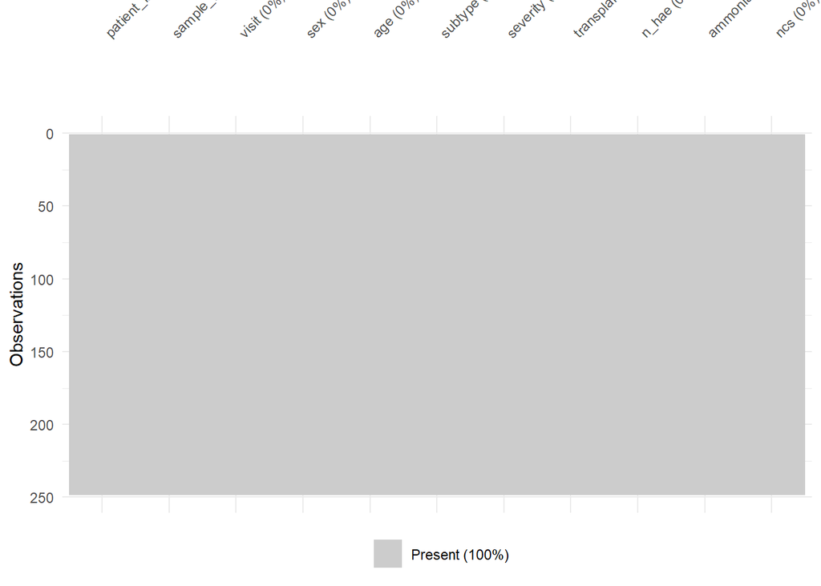

```r
vis_miss(clinical)
```

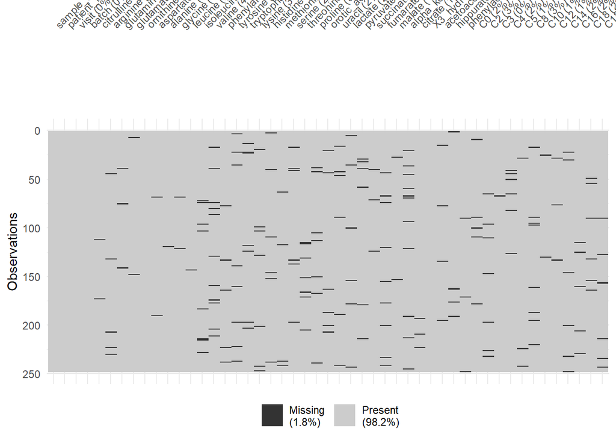

```r
vis_miss(metabol)
```

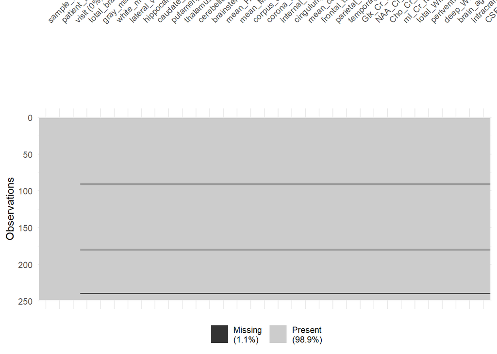

```r
vis_miss(radiomics)
```

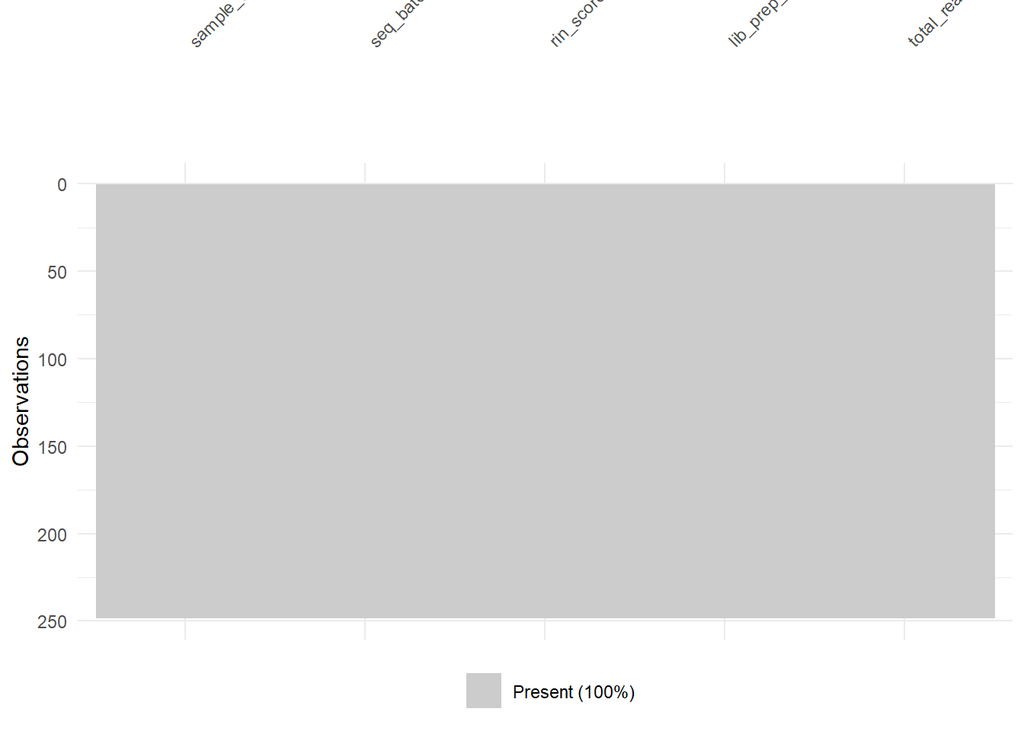

```r
vis_miss(rnameta)
```

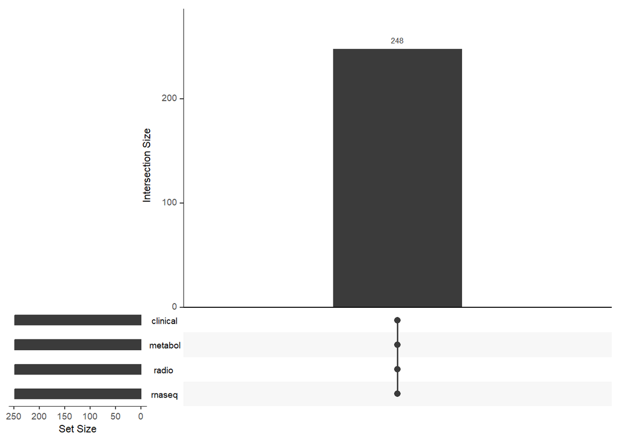

```r
samples_by_modality <- list(
  clinical = clinical$sample_id,
  metabol  = metabol$sample_id,
  radio    = radiomics$sample_id,
  rnaseq   = intersect(colnames(rnacounts), rnameta$sample_id)
)

p <- fromList(samples_by_modality) %>% upset()

p
```

```r
png("part1/samples_modal.png", height = 4, width = 6.8, units = "in", res = 300)
fromList(samples_by_modality) %>% upset()
dev.off()
```

**Interpretation:** The UpSet plot revealed that all 248 samples have complete data across all four modalities (clinical, metabolomics, radiomics, and RNA-seq), as shown by a single intersection bar at 248. Set sizes are nearly identical across modalities (~250 each). This unexpectedly complete multimodal coverage simplifies cross-modality alignment at the sample level, though it does not preclude feature-level missingness within individual modalities.

## 1.6 Metabolomics QC

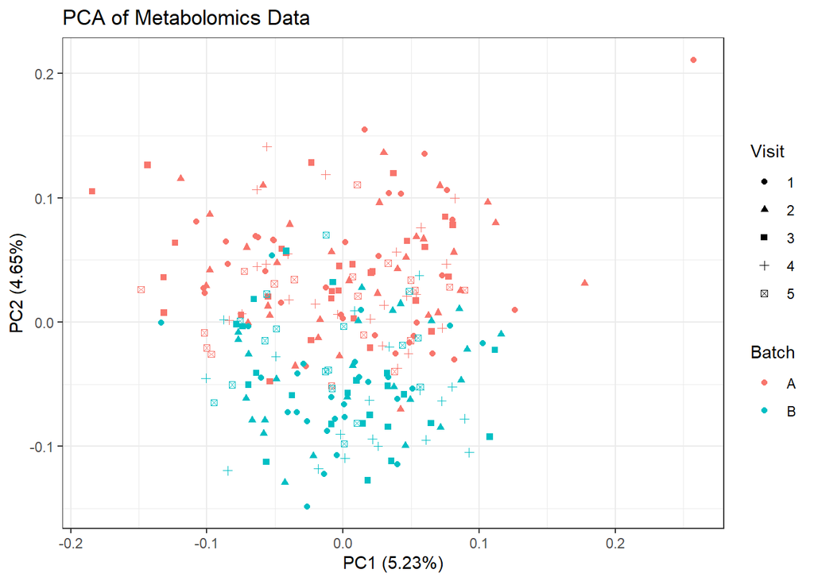

```r
metabol$visit <- factor(metabol$visit)
metabol$batch <- factor(metabol$batch)

numeric_metab <- metabol %>% select(where(is.numeric))

metab_imputed <- numeric_metab %>%
  mutate(across(everything(), ~ ifelse(is.na(.), median(., na.rm=TRUE), .)))

metab_scaled <- scale(metab_imputed)
pca <- prcomp(metab_scaled)

p <- autoplot(
  pca,
  data = metabol,
  colour = "batch",
  shape = "visit"
) +
  theme_bw() +
  labs(
    title = "PCA of Metabolomics Data",
    color = "Batch",
    shape = "Visit")

p
```

```r
ggsave("part1/metabolomics_pca.png", p, height=4, width=6.8, dpi=300)
```